# Red Red Wine by Laura Yoshizawa

### Impact of Citric Acid and Volatile Acidity on Quality

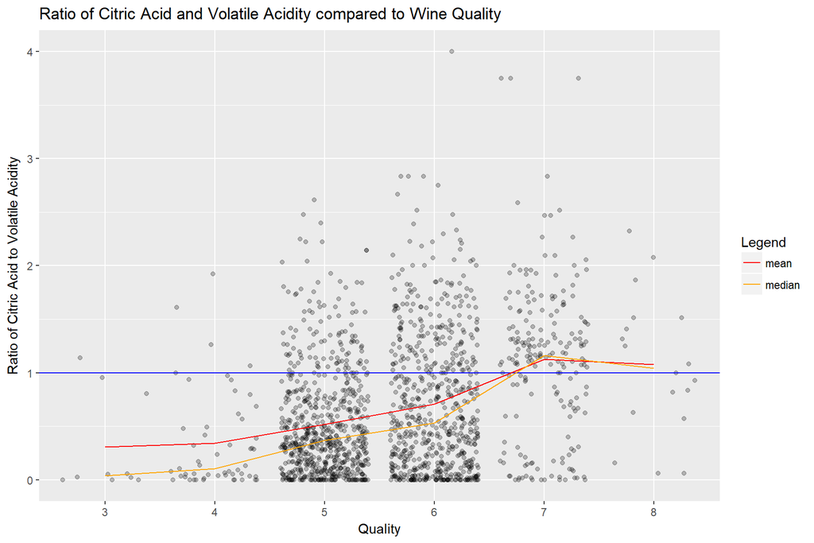

This plot looks at the ratio of Citric Acid and Volatile Acidity and compares them by quality. the mean and median ratios are plotted on the above table in red and orange respectively. This diagram shows that as the ratio increases, the quality of the wine increases as well. In fact, of the top quality wines, rated 7 and 8, the mean and median wines have a ratio greater than 1. This means higher quality wines contain more citric acid than volatile acidity.

# Reflection

This red wine dataset contains information on 1599 different wines, with 11 physical features and 1 subjective feature. This subjective feature is quality, and was determined by a panel of three wine experts. To explore this dataset, one question stood out: What determines the quality of each wine?

From the initial examination of data, I thought that acids, sulfurs, and sulphates would be the biggest contributor towards wine quality. However the feature that correlated the highest with quality was neither of them: it was alcohol content. While larger amounts of alcohol doesn’t cause higher quality, wines with larger alcohol by volume amounts tended to be rated higher by the wine experts.

Citric acid and volatile acidity also were correlated with the quality of the wines as well: Citric acid had a positive correlation, while volatile acid had a negative correlation. Their inverse relationship with quality interested me, so I not only investigated the relationship between the two acids, but the ratio of the two when compared to quality as well. This lead to the observation that wines with a higher citric acid to volatile acidity ratio tend to have a higher quality.

Another interesting observation from the dataset is how fixed acidity has a strong correlation with pH and citric acid. Hoewver when a plot was faceted by quality, it didn’t appear that fixed acidity had a correlation with quality.  
But when fixed acidity was plotted with density, it appears that higher quality wines have lower densities compared to other wines with the same amount of fixed acidity.

Because this dataset is mostly composed of the chemical composition of these wines, there are a lot of limitations on this analysis. The length of fermentation, types of grapes used, type of container the wine was fermented in (wood or plastic? what type of wood?), and other additives contribute to the quality of wine, but were not included in the dataset. Additionally, it would be interesting to know the year of some wines, to see if the wines maintain the same chemical properties every year, or what values change.